# Structural Divergence Analysis

MarÃa Laura Marcos, Julian Echave

# Introduction

We study the evolutionary divergence of proteins using the LF-ENM and comparing simulated mutants with experimental data.

We use the ANM Elastic Network Model with `R0 =` 10 for the cys family. We use as reference for the ENM the protein with pdb code 1cqda. The cys family consists of the following proteins:

```
##  [1] "1mema"  "1icfa1" "8pcha"  "1gece"  "1ppo"   "1ppn"   "1yal"
##  [8] "2act"   "1aim"   "1thea"  "1huca"  "1deua"
```

# Structural divergence along sites

Here we study how structural divergence varies from site to site. We will compare simulated data and empirical data.

### Mean z.RSD vs site

To measure structural divergence we use z.RSD profiles, which are the best (most similar distributions and profiles w.r.t experimental).

The following plot compares the mean z.RSD profiles, including standard errors (with .999 confidence level for the mean) *Warning: the effective number of data should be smaller than the actual data, especially for the experimental dataset because of several factors, including smoothing of the profiles, phylogenetic relationships, etc. We need to deal with this for quantitative analysis. Probably we’ll need to use bootstrapping to calculate standard errors non-parametrically*

[figure not shown]

[figure not shown]

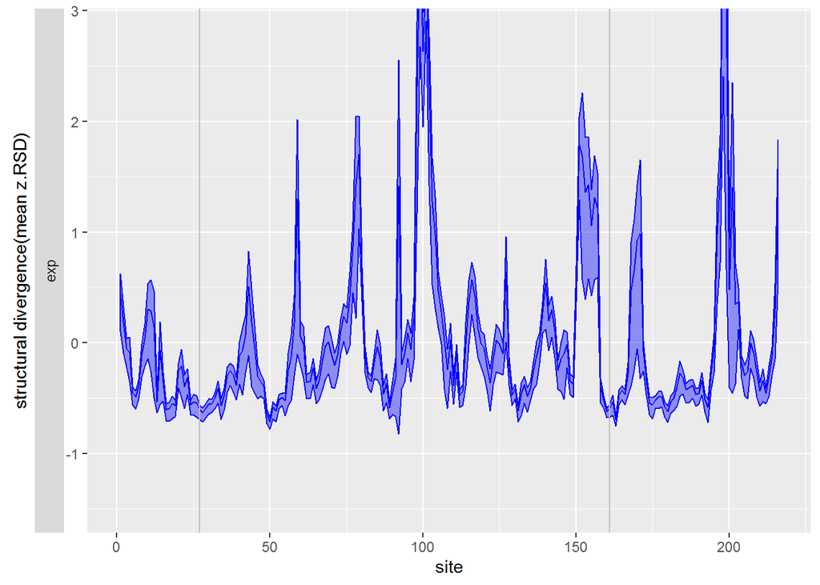

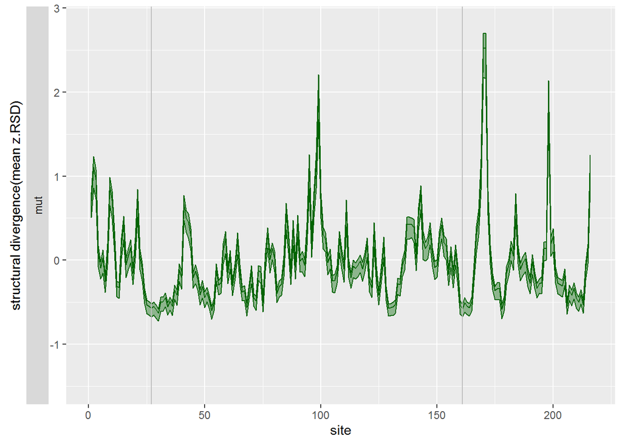

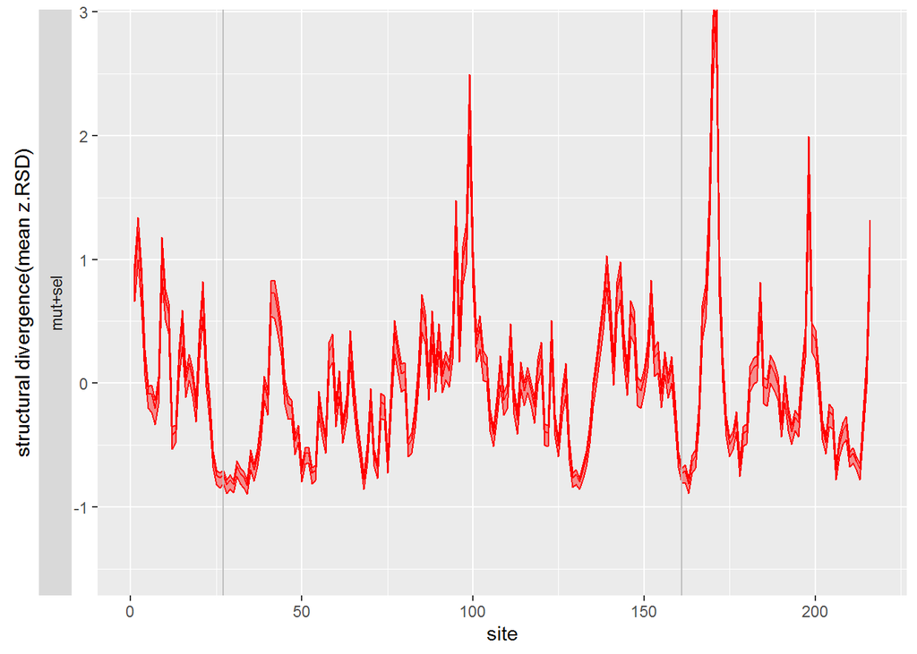

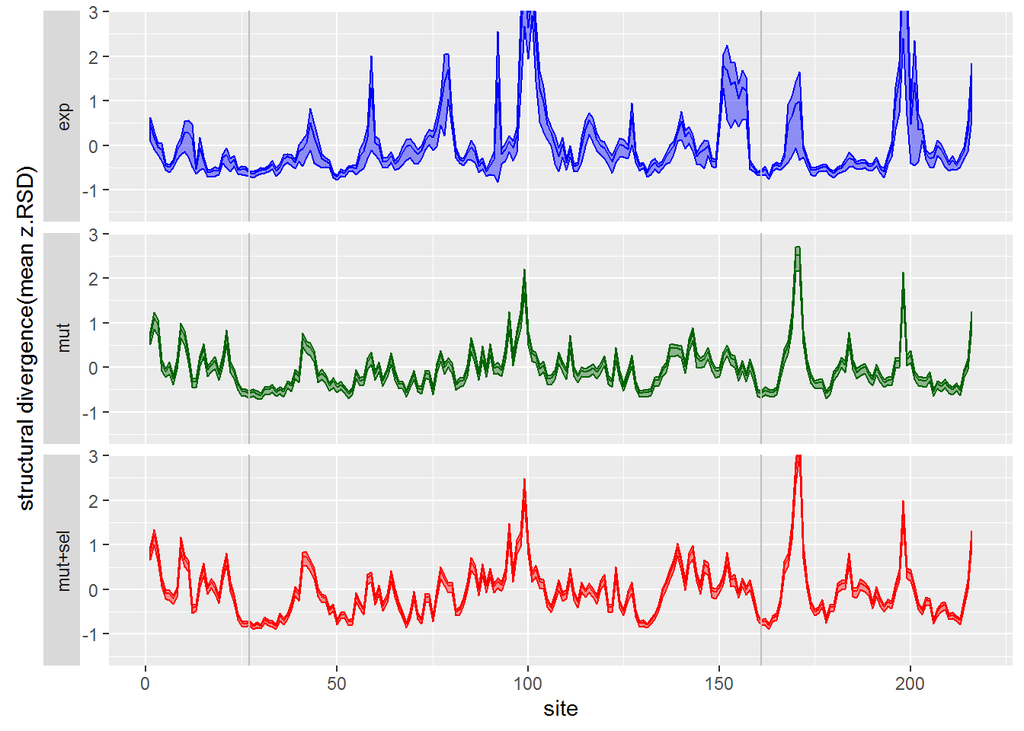

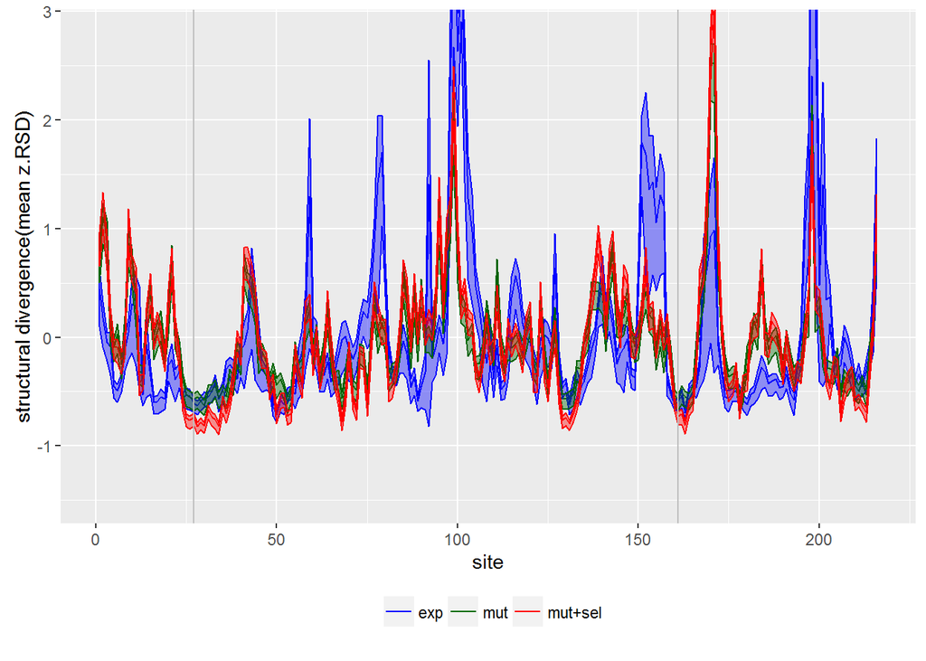

### Correlation between site profiles

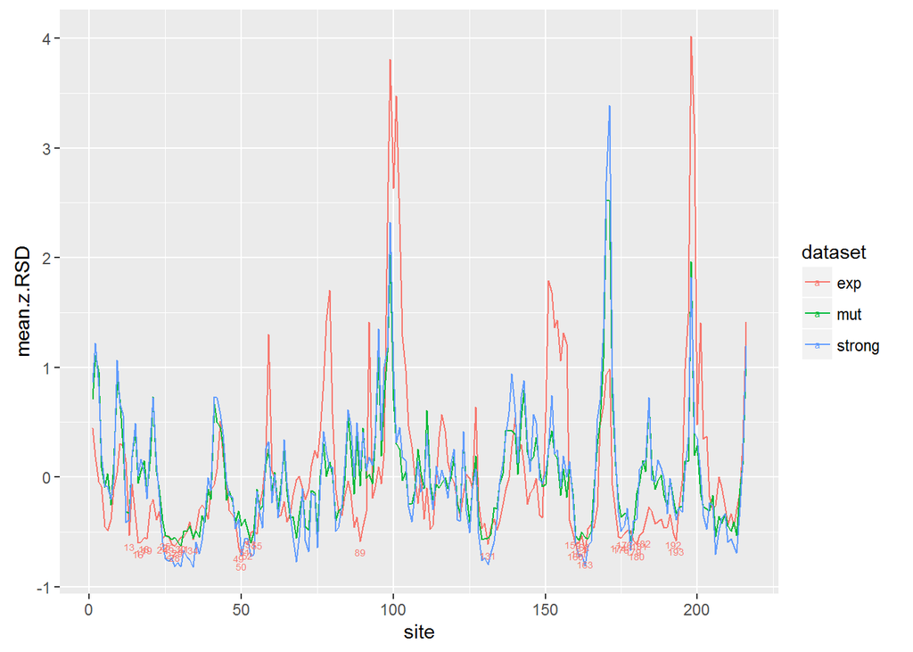

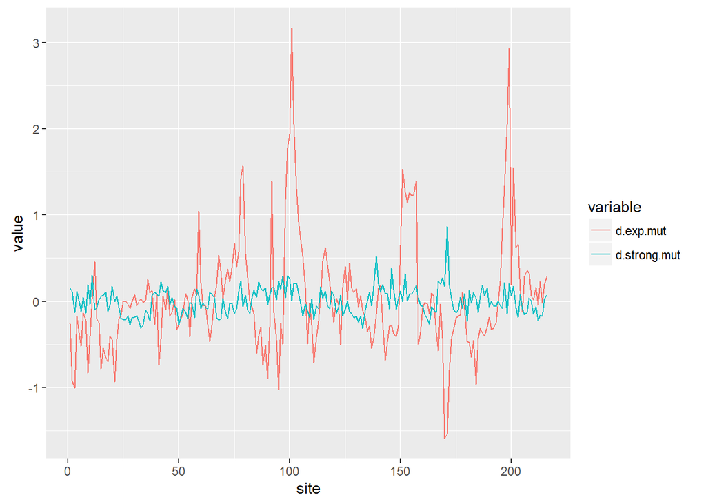

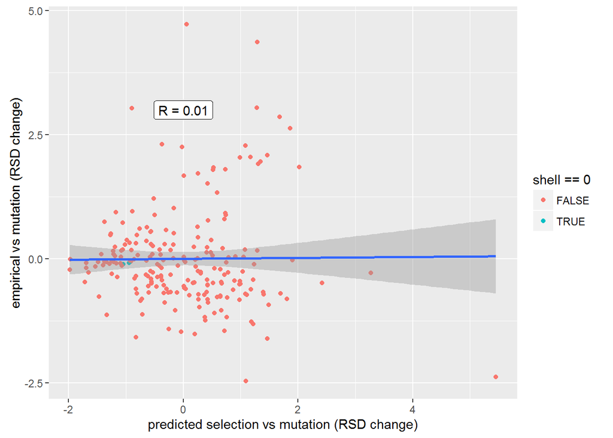

| comparison | R |
| --- | --- |
| exp vs mut | 0.54 |
| exp vs strong | 0.55 |
| mut vs strong | 0.98 |

# Structural divergence along normal modes

In this section we consider structural divergence using normal mode coordinates. Pn is the square divergence along a normal mode relative to the mean.

### Pn vs. mode energy

Note: lines are the median, 0.05 and 0.95 quantiles fit using rq(Pn ~ sn2). sn2 = 1/energy is the expected MSD of along mode n. The mean value of Pn should be a linear function of sn2 (Pn is normalized, sn2 is not).

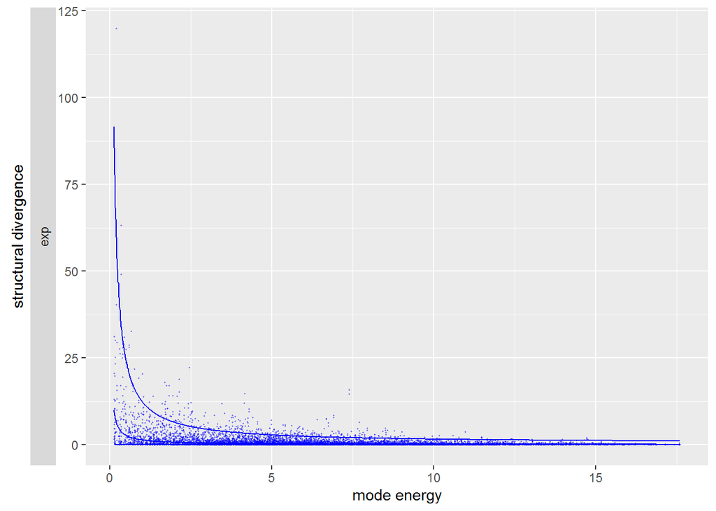

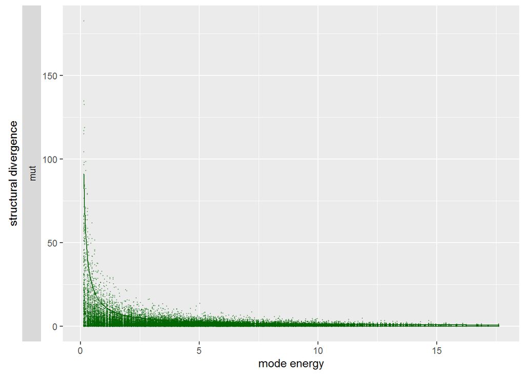

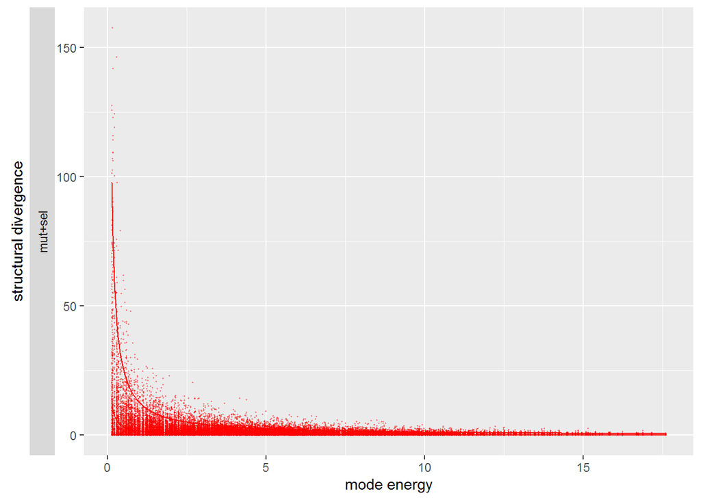

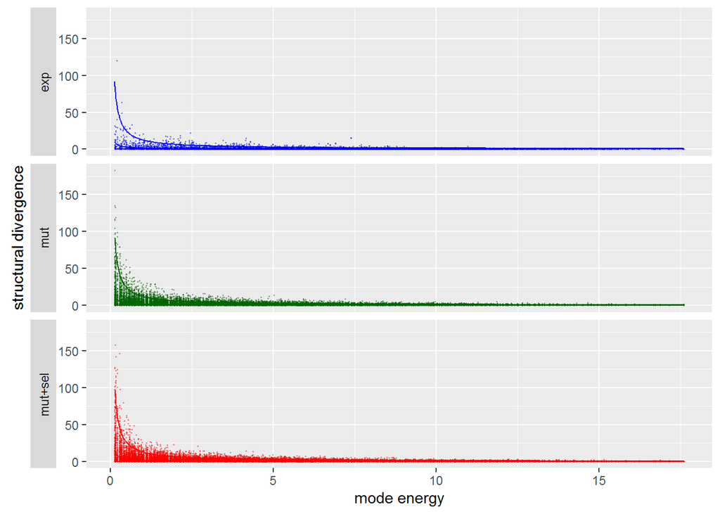

### median(Pn) vs mode energy

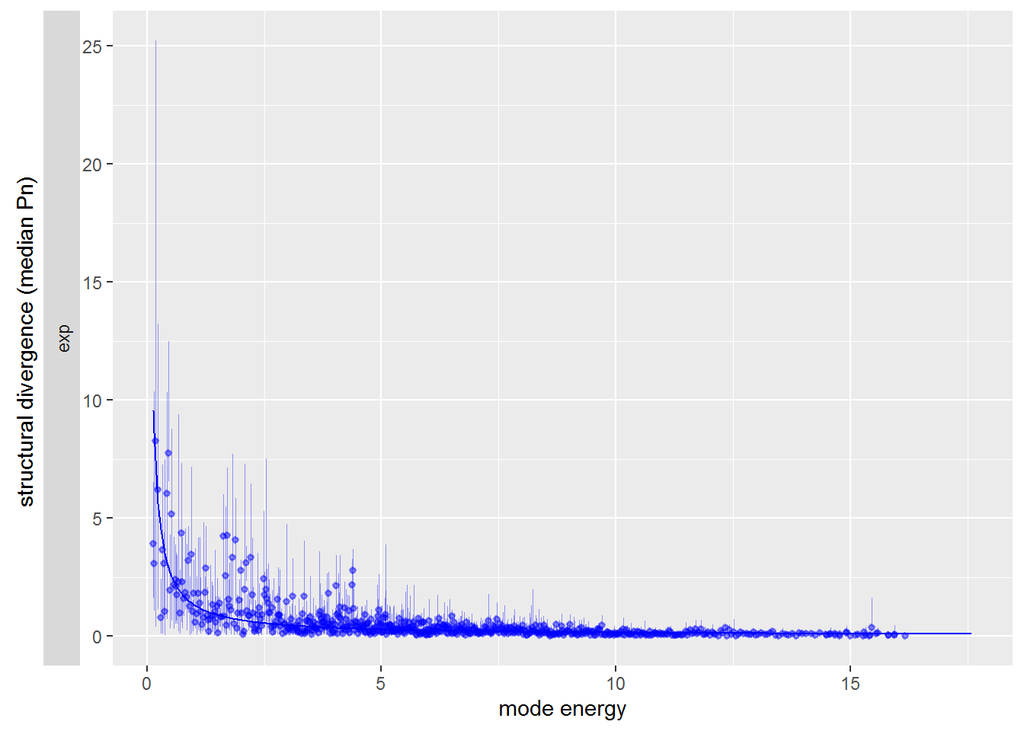

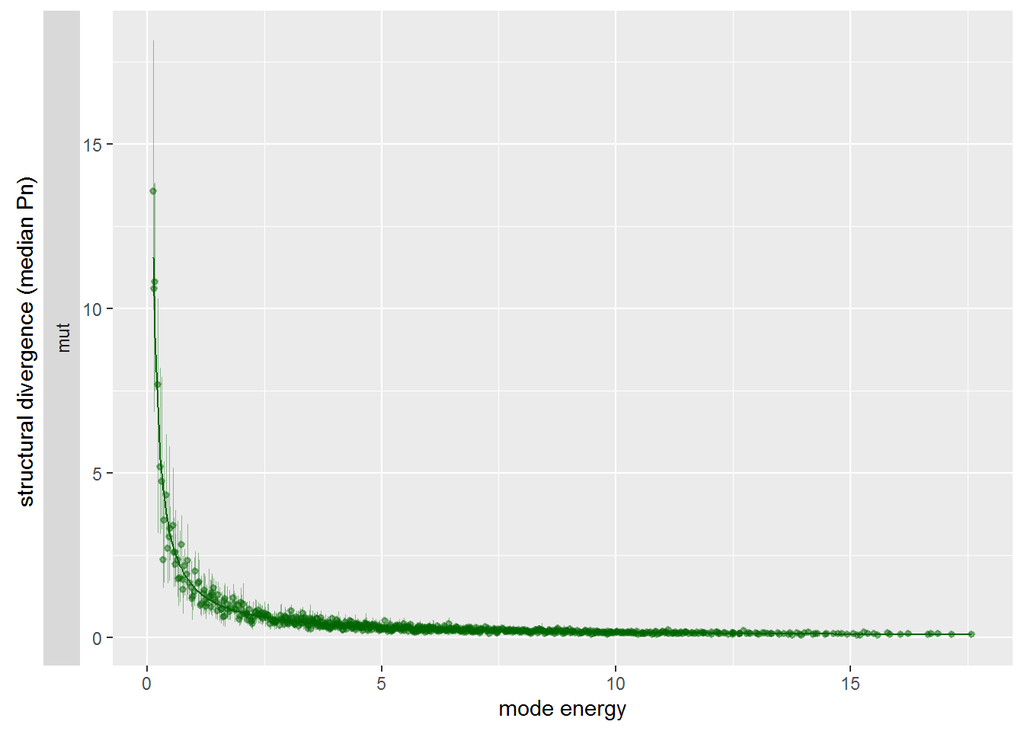

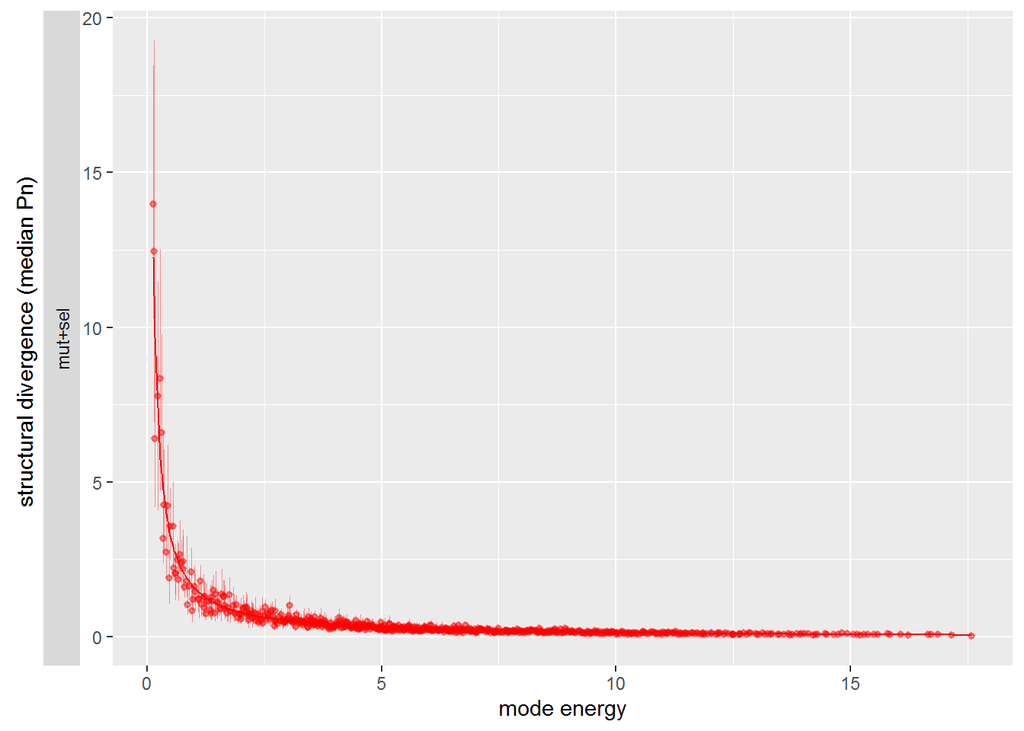

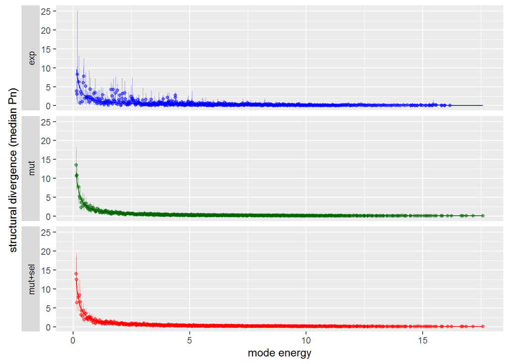

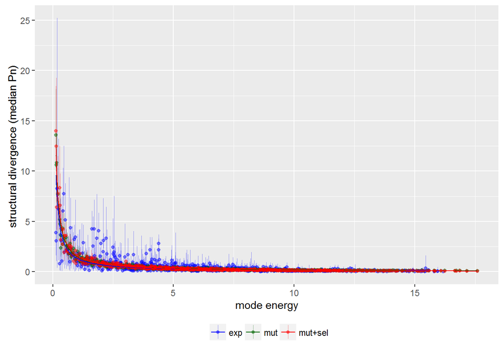

### Correlation between mode profiles

| comparison | R |
| --- | --- |
| exp vs mut | 0.56 |
| exp vs strong | 0.48 |
| mut vs strong | 0.94 |